# Feature Engineering Project_Hemlata

### Project 4: Featurization and Model Tuning Project

The actual concrete compressive strength (MPa) for a given mixture under a specific age (days) was determined from laboratory. Data is in raw form (not scaled). The data has 8 quantitative input variables, and 1 quantitative output variable, and 1030 instances (observations).

### Data Description:

### Domain: Cement manufacturing

### Context:

Concrete is the most important material in civil engineering. The concrete compressive strength is a highly nonlinear function of age and ingredients. These ingredients include cement, blast furnace slag, fly ash, water, superplasticizer, coarse aggregate, and fine aggregate.

### Attribute Information:

#### Cement:measured in kg in a m3 mixture

#### Blast: measured in kg in a m3 mixture

#### Fly ash: measured in kg in a m3 mixture

#### Water: measured in kg in a m3 mixture

#### Superplasticizer: measured in kg in a m3 mixture

#### Coarse Aggregate: measured in kg in a m3 mixture

#### Fine Aggregate: measured in kg in a m3 mixture

#### Age: day (1~365)

#### Concrete compressive strength: measured in MPa

### Learning Outcomes:

Exploratory Data Analysis Building ML models for regression Hyper parameter tuning

### Objective:

Modeling of strength of high performance concrete using Machine Learning

## Steps and tasks

### 1. Deliverable -1 (Exploratory data quality report reflecting the following)

### (20 marks)

### a. Univariate analysis (5 marks)

#### i. Univariate analysis –

#### 1) data types and description of the independent attributes which should include (name,meaning, range of values observed, central values (mean and median), standard deviation and quartiles

#### using pandas dataframe's describe function

#### 2) analysis of the body of distributions / tails

#### 3) missing values

#### using dataframe's info function or dataframe's isnull function

#### 4) outliers

#### Boxplots of all attributes

```python
import numpy as np # linear algebra
import pandas as pd # data processing, CSV file I/O (e.g. pd.read_csv)
import matplotlib.pyplot as plt       # matplotlib.pyplot plots data
%matplotlib inline

import seaborn as sns
from sklearn.model_selection import train_test_split
from sklearn.impute import SimpleImputer
import sklearn.tree as DecisionTreeClassifier
from scipy.stats import zscore
from sklearn import metrics
```

## Task 1: 1. Load the dataset

```python
Data = pd.read_csv("concrete.csv")
Data.head()
```

|  | cement | slag | ash | water | superplastic | coarseagg | fineagg | age | strength |
| --- | --- | --- | --- | --- | --- | --- | --- | --- | --- |
| 0 | 141.3 | 212.0 | 0.0 | 203.5 | 0.0 | 971.8 | 748.5 | 28 | 29.89 |
| 1 | 168.9 | 42.2 | 124.3 | 158.3 | 10.8 | 1080.8 | 796.2 | 14 | 23.51 |
| 2 | 250.0 | 0.0 | 95.7 | 187.4 | 5.5 | 956.9 | 861.2 | 28 | 29.22 |
| 3 | 266.0 | 114.0 | 0.0 | 228.0 | 0.0 | 932.0 | 670.0 | 28 | 45.85 |
| 4 | 154.8 | 183.4 | 0.0 | 193.3 | 9.1 | 1047.4 | 696.7 | 28 | 18.29 |

```python
## to observe dataset size i.e. #rows and #columns
Data.shape
```

```
(1030, 9)
```

```python
Data.age.value_counts()
```

```
28     425
3      134
7      126
56      91
14      62
90      54
100     52
180     26
91      22
365     14
270     13
360      6
120      3
1        2
Name: age, dtype: int64
```

```python
Data.dtypes
```

```
cement          float64
slag            float64
ash             float64
water           float64
superplastic    float64
coarseagg       float64
fineagg         float64
age               int64
strength        float64
dtype: object
```

### All columns are numeric

```python
## Range of each column
minval = pd.Series(Data.min())
maxval = pd.Series(Data.max())
rangeD = pd.Series(Data.max()-Data.min())
rangeData = pd.DataFrame({'min':minval,'max':maxval,'range':rangeD}, columns=['min','max','range'])
rangeData
```

|  | min | max | range |
| --- | --- | --- | --- |
| cement | 102.00 | 540.0 | 438.00 |
| slag | 0.00 | 359.4 | 359.40 |
| ash | 0.00 | 200.1 | 200.10 |
| water | 121.80 | 247.0 | 125.20 |
| superplastic | 0.00 | 32.2 | 32.20 |
| coarseagg | 801.00 | 1145.0 | 344.00 |
| fineagg | 594.00 | 992.6 | 398.60 |
| age | 1.00 | 365.0 | 364.00 |
| strength | 2.33 | 82.6 | 80.27 |

### by observing mean and median of each column

### the columns 'ash', 'slag' has larger difference in mean and median

```python
pd.DataFrame({'median':Data.median(),'mean':Data.mean()})
```

|  | median | mean |
| --- | --- | --- |
| cement | 272.900 | 281.167864 |
| slag | 22.000 | 73.895825 |
| ash | 0.000 | 54.188350 |
| water | 185.000 | 181.567282 |
| superplastic | 6.400 | 6.204660 |
| coarseagg | 968.000 | 972.918932 |
| fineagg | 779.500 | 773.580485 |
| age | 28.000 | 45.662136 |
| strength | 34.445 | 35.817961 |

```python
## to see the central tendancy
Data.describe().transpose()
```

|  | count | mean | std | min | 25% | 50% | 75% | max |
| --- | --- | --- | --- | --- | --- | --- | --- | --- |
| cement | 1030.0 | 281.167864 | 104.506364 | 102.00 | 192.375 | 272.900 | 350.000 | 540.0 |
| slag | 1030.0 | 73.895825 | 86.279342 | 0.00 | 0.000 | 22.000 | 142.950 | 359.4 |
| ash | 1030.0 | 54.188350 | 63.997004 | 0.00 | 0.000 | 0.000 | 118.300 | 200.1 |
| water | 1030.0 | 181.567282 | 21.354219 | 121.80 | 164.900 | 185.000 | 192.000 | 247.0 |
| superplastic | 1030.0 | 6.204660 | 5.973841 | 0.00 | 0.000 | 6.400 | 10.200 | 32.2 |
| coarseagg | 1030.0 | 972.918932 | 77.753954 | 801.00 | 932.000 | 968.000 | 1029.400 | 1145.0 |
| fineagg | 1030.0 | 773.580485 | 80.175980 | 594.00 | 730.950 | 779.500 | 824.000 | 992.6 |
| age | 1030.0 | 45.662136 | 63.169912 | 1.00 | 7.000 | 28.000 | 56.000 | 365.0 |
| strength | 1030.0 | 35.817961 | 16.705742 | 2.33 | 23.710 | 34.445 | 46.135 | 82.6 |

```
array([[<matplotlib.axes._subplots.AxesSubplot object at 0x7fdbe098a750>,
      dtype=object)
```

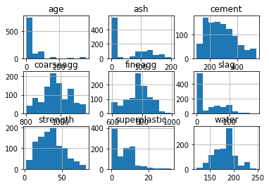

```python
## to see the distribution, plot histograms
Data.hist()
```

### From histograms it can be observed that the columns 'strength','coarseagg','fineagg','water' are normally distributed.

### the columns 'superplastic','age', 'cement' has tails to the right

### also columns 'slag', 'ash','age' are not npormally distributed.

```python
## checking for missing values
Data.isnull().sum()
```

```
cement          0
slag            0
ash             0
water           0
superplastic    0
coarseagg       0
fineagg         0
age             0
strength        0
dtype: int64
```

### There are no any missing values in the dataset.

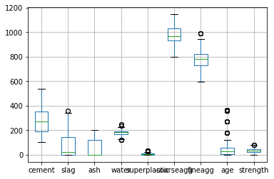

```python
Data.boxplot()
```

### The columns 'water','superplastic','fineagg','age','strength' shows outliers.

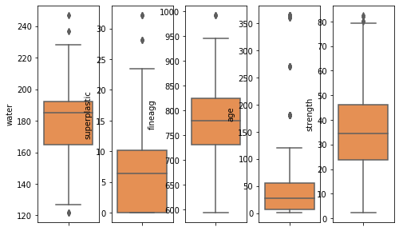

```python
fig,ax = plt.subplots(1,5,figsize=(8,5))
sns.boxplot(ax=ax[0],y=Data['water'],palette="Oranges")
sns.boxplot(ax=ax[1],y=Data['superplastic'],palette="Oranges")
sns.boxplot(ax=ax[2],y=Data['fineagg'],palette="Oranges")
sns.boxplot(ax=ax[3],y=Data['age'],palette="Oranges")
sns.boxplot(ax=ax[4],y=Data['strength'],palette="Oranges")
plt.show()
```

## Step 1:

### b. Multivariate analysis (5 marks)

### i. Bi-variate analysis between the predictor variables and between predictor variables and target column.

### Comment on your findings in terms of their relationship and degree of relation if any. Presence of leverage points.

### Visualize the analysis using boxplots and pair plots, histograms or density curves.

### Select the most appropriate attributes

### Findings from the pairplots:

#### There is somewhat linear relationship between 'cement' and 'sterength'

#### The columns 'water' and 'superplastic' and 'water' and 'fineagg' , 'water' and 'coarseagg' also shows somewhat linear relationship.

```python
import warnings
warnings.filterwarnings('ignore')
```

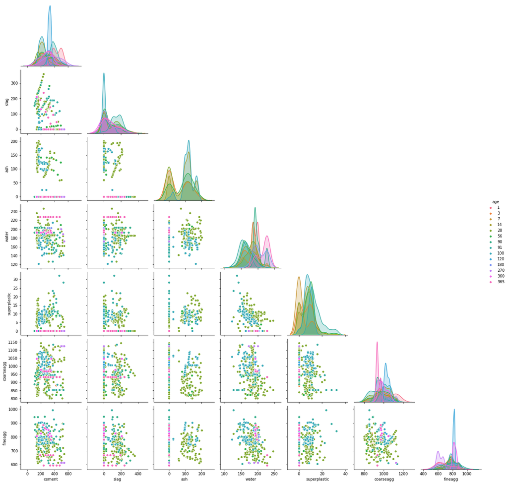

```python
X = Data.drop('strength',axis=1)
sns.pairplot(X, corner=True,hue='age')
plt.show()
```

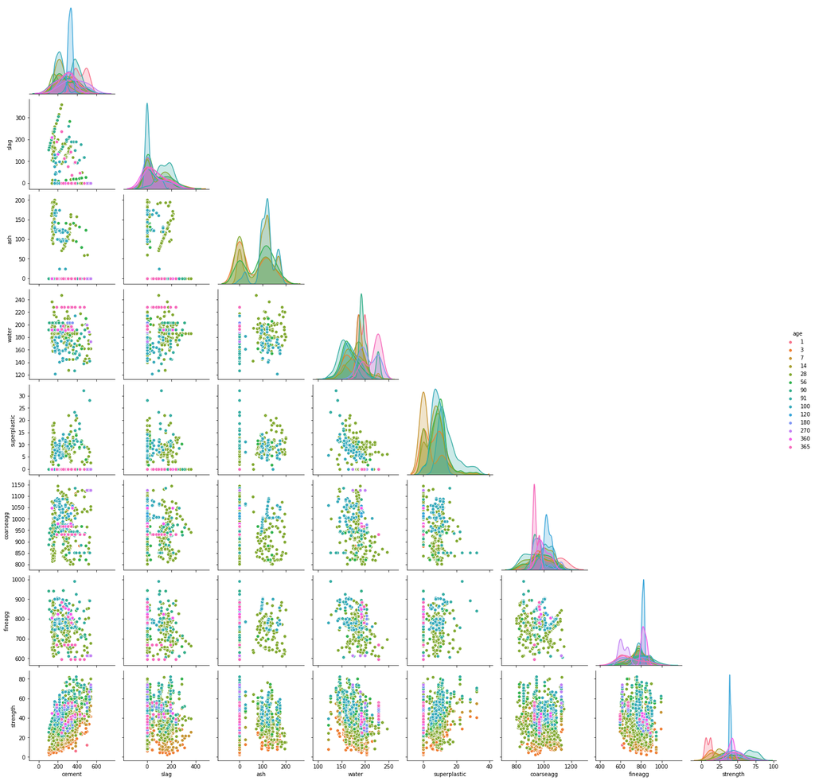

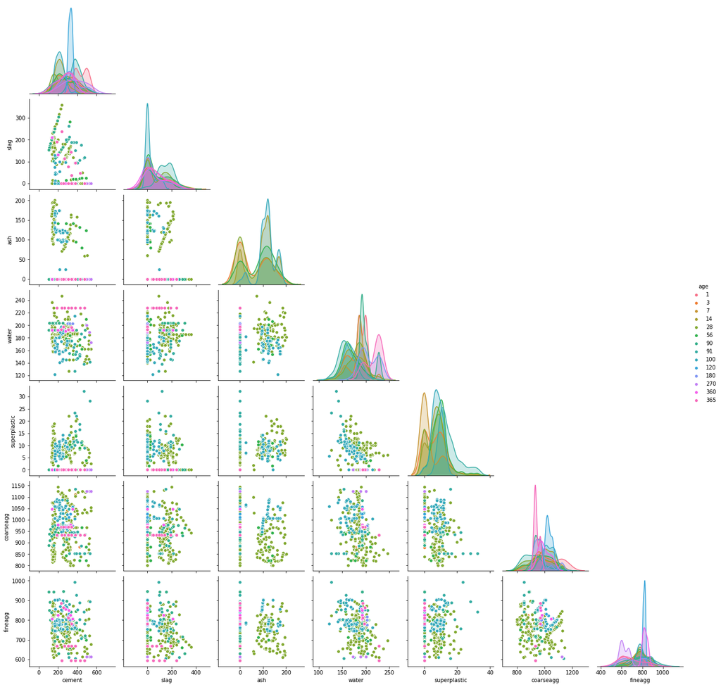

```python
sns.pairplot(Data,corner=True,hue='age')
sns.pairplot(X, diag_kind= 'kde', corner=True,hue='age')
```

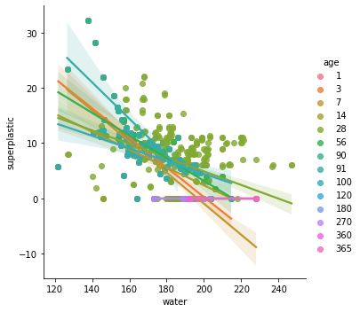

```python
plt.figure(figsize=(5,5))
sns.lmplot('water','superplastic',hue='age',data=Data)
```

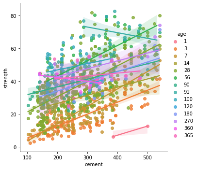

```python
plt.figure(figsize=(5,5))
sns.lmplot('cement','strength',hue='age',data=Data)
```

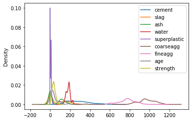

```python
## Also using density plots data distribution can be observed
plt.figure(figsize=(5,5))
Data.plot.density()
```

## Step 1

c. Pick one strategy to address the presence outliers and missing values and perform necessary imputation (10 marks)

### There are no any missing values in the dataset. If missing values exists, those can be imputed based on the median of the column and be replaced with median.

### For outliers use zscore from stats.zscore and remove the data with more han 3 standard deviations, also use IQR and remove values which are below 1.5 *IQR i.e. of 25% quantile and above 1.5* IQR above 75 % quantile.

```python
from scipy import stats
z = np.abs(stats.zscore(Data))
#print(z)
```

```python
threshold = 3
print(np.where(z < 3))
```

```
(array([   0,    0,    0, ..., 1029, 1029, 1029]), array([0, 1, 2, ..., 6, 7, 8]))
```

```python
Q1 = Data.quantile(0.25)
Q3 = Data.quantile(0.75)
IQR = Q3 - Q1
#print(IQR)
```

```python
Data_out = Data[(z < 3).all(axis=1)]
Data_out.shape
```

```
(981, 9)
```

```python
Data_out1 = Data_out[~((Data_out < (Q1 - 1.5 * IQR)) |(Data_out > (Q3 + 1.5 * IQR))).any(axis=1)]
Data_out1.shape
```

```
(939, 9)
```

### The dataset rows are reduced after removing outliers

```python
#Data_out1.boxplot()
```

```python
Data_out1.cov()
```

|  | cement | slag | ash | water | superplastic | coarseagg | fineagg | age | strength |
| --- | --- | --- | --- | --- | --- | --- | --- | --- | --- |
| cement | 10398.451382 | -2291.207410 | -2463.601546 | -169.169100 | 16.813552 | -790.565296 | -1847.127656 | -107.337053 | 807.309765 |
| slag | -2291.207410 | 7319.849652 | -1924.234344 | 181.719715 | 23.869474 | -1938.311623 | -1859.985515 | -82.378594 | 205.404127 |
| ash | -2463.601546 | -1924.234344 | 4144.359348 | -302.205689 | 155.616639 | -194.991349 | 297.981569 | 99.122620 | -59.148189 |
| water | -169.169100 | 181.719715 | -302.205689 | 352.217943 | -64.275355 | -303.817742 | -512.545238 | -11.754983 | -115.062041 |
| superplastic | 16.813552 | 23.869474 | 155.616639 | -64.275355 | 28.502750 | -93.601237 | 44.549648 | 6.760715 | 35.708797 |
| coarseagg | -790.565296 | -1938.311623 | -194.991349 | -303.817742 | -93.601237 | 6041.074015 | -1054.553017 | 47.879871 | -217.337619 |
| fineagg | -1847.127656 | -1859.985515 | 297.981569 | -512.545238 | 44.549648 | -1054.553017 | 5625.937830 | 95.035101 | -196.712865 |
| age | -107.337053 | -82.378594 | 99.122620 | -11.754983 | 6.760715 | 47.879871 | 95.035101 | 816.629831 | 245.420114 |
| strength | 807.309765 | 205.404127 | -59.148189 | -115.062041 | 35.708797 | -217.337619 | -196.712865 | 245.420114 | 275.695284 |

### Observing covariance shows ash,superplastic columns has low covariance with target column 'strength'

## Step 2: Deliverable -2 (Feature Engineering techniques) (15 marks)

#### a. Identify opportunities (if any) to create a composite feature, drop a

feature etc. (5 marks)

#### b. Decide on complexity of the model, should it be simple linear

model in terms of parameters or would a quadratic or higher degree help (5 marks)

#### c. Explore for gaussians. If data is likely to be a mix of gaussians,

explore individual clusters and present your findings in terms of the independent attributes and their suitability to predict strength (5 marks)

```python
X = Data_out1.drop('strength', axis=1)
y = Data_out1[['strength']]
```

```python
from sklearn import preprocessing

# scale all the columns of the Data. This will produce a numpy array
X_scaled = preprocessing.scale(X)
X_scaled = pd.DataFrame(X_scaled, columns=X.columns)  # ideally the training and test should be

y_scaled = preprocessing.scale(y)
y_scaled = pd.DataFrame(y_scaled, columns=y.columns)  # ideally the training and test should be
```

```python
from sklearn.model_selection import train_test_split
X_train, X_test, y_train, y_test = train_test_split(X_scaled, y_scaled, test_size=0.30, random_state=42)
```

```python
## Removing Constant Features using Variance Threshold
from sklearn.feature_selection import VarianceThreshold
constant_filter = VarianceThreshold(threshold=0.1)
constant_filter.fit(X_train)

len(X_train.columns[constant_filter.get_support()])

constant_columns = [column for column in X_train.columns
                    if column not in X_train.columns[constant_filter.get_support()]]

X_train = X_train.drop(labels=constant_columns, axis=1)
X_test= X_test.drop(labels=constant_columns, axis=1)
```

```python
X_train.shape
```

```
(657, 8)
```

## Step 3. Deliverable -3 (create the model ) ( 15 marks)

a. Obtain feature importance for the individual features and present your findings

### no features have been dropeed

```python
correlated_features = set()
correlation_matrix = X_train.corr()
```

```python
correlation_matrix
```

|  | cement | slag | ash | water | superplastic | coarseagg | fineagg | age |
| --- | --- | --- | --- | --- | --- | --- | --- | --- |
| cement | 1.000000 | -0.249398 | -0.379394 | -0.083368 | 0.003944 | -0.126952 | -0.210680 | -0.084761 |
| slag | -0.249398 | 1.000000 | -0.355701 | 0.135047 | 0.049369 | -0.315481 | -0.298498 | 0.000670 |
| ash | -0.379394 | -0.355701 | 1.000000 | -0.235004 | 0.453543 | -0.012106 | 0.031382 | 0.094561 |
| water | -0.083368 | 0.135047 | -0.235004 | 1.000000 | -0.619415 | -0.212023 | -0.392244 | -0.025862 |
| superplastic | 0.003944 | 0.049369 | 0.453543 | -0.619415 | 1.000000 | -0.234173 | 0.125545 | 0.061521 |
| coarseagg | -0.126952 | -0.315481 | -0.012106 | -0.212023 | -0.234173 | 1.000000 | -0.158325 | 0.026917 |
| fineagg | -0.210680 | -0.298498 | 0.031382 | -0.392244 | 0.125545 | -0.158325 | 1.000000 | 0.017085 |
| age | -0.084761 | 0.000670 | 0.094561 | -0.025862 | 0.061521 | 0.026917 | 0.017085 | 1.000000 |

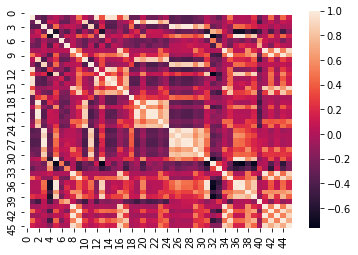

```python
from sklearn.preprocessing import PolynomialFeatures
from sklearn import linear_model
poly = PolynomialFeatures(degree=2, interaction_only=True)
Data2 = poly.fit_transform(Data_out1)
Data3 = pd.DataFrame(Data2)
corr_matrix = Data3.corr()
corr_matrix
sns.heatmap(corr_matrix)
```

```python
Data3.shape
```

```
(939, 46)
```

```python
target_feature_names = ['x'.join(['{}^{}'.format(pair[0],pair[1]) for pair in tuple if pair[1]!=0]) for tuple in [zip(Data_out1.columns,p) for p in poly.powers_]]
output_df = pd.DataFrame(Data2, columns = target_feature_names)
```

```python
output_df['strength'] = output_df['strength^1']
output_df.drop('strength^1', axis=1,inplace=True)
X = output_df.drop('strength', axis=1)
y = output_df['strength']
```

```python
#output_df.head()
```

```python
X_train1, X_test1, y_train1, y_test1 = train_test_split(X, y, test_size=0.30, random_state=42)
```

Model building

### Linear Regression Model on preprocessed data and standard scaling

```python
# Build Linear Reg  to use in feature selection
from sklearn.linear_model import LinearRegression
from sklearn.pipeline import Pipeline
from sklearn.preprocessing import StandardScaler
```

```python
pipeline_LR = Pipeline([
    ('scaler',StandardScaler()),
    ('LR_linear', LinearRegression())
])

# use the pipeline object as you would
# a regular classifier
pipeline_LR.fit(X_train,y_train)
```

```
Pipeline(steps=[('scaler', StandardScaler()),
                ('LR_linear', LinearRegression())])
```

### Linear regression using original features- linear model

Able to get 76% accuracy on training data and 77% accuracy on test data

```python
pipeline_LR.score(X_train,y_train)
```

```
0.7642772575377559
```

```python
pipeline_LR.score(X_test,y_test)
```

```
0.7751382129341633
```

### Linear regression using polynomial features

Give 99 % accuracy on both train and test data

```python
#LR = LinearRegression()
pipeline_PLR = Pipeline([
    ('scaler',StandardScaler()),
    ('LR', LinearRegression())
])

# use the pipeline object as you would
# a regular classifier
pipeline_PLR.fit(X_train1,y_train1)
#LR.fit(X_train1, y_train1)
```

```
Pipeline(steps=[('scaler', StandardScaler()), ('LR', LinearRegression())])
```

```python
pipeline_PLR.score(X_train1, y_train1)
```

```
0.9999500768406955
```

```python
pipeline_PLR.score(X_test1, y_test1)
```

```
0.9999127222808513
```

### Applying feature selector

```python
from mlxtend.feature_selection import SequentialFeatureSelector as sfs
LR = LinearRegression()
sfs1 = sfs(LR, k_features=12, forward=True, scoring='r2', cv=5)
```

```python
# Perform SFFS
sfs1 = sfs1.fit(X_train1.values, y_train1.values)
```

```python
#sfs1.get_metric_dict()
```

```python
feat_cols = list(sfs1.k_feature_idx_)
print(feat_cols)
xsel_train = X_train1.iloc[:, feat_cols]
```

```
[4, 6, 7, 9, 13, 16, 23, 24, 29, 34, 41, 43]
```

```python
LR.fit(xsel_train, y_train1)

y_train_pred = LR.predict(X_train1.iloc[:, feat_cols])
```

```python
from sklearn.metrics import r2_score as acc
acc(y_train1, y_train_pred)
```

```
0.9997111903915499
```

```python
LR.score(xsel_train, y_train1)
```

```
0.9997111903915499
```

```python
xsel_test = X_test1.iloc[:, feat_cols]
LR.score(xsel_test, y_test1)
```

```
0.9996261446370437
```

```python
# Import Linear Regression machine learning library
from sklearn.tree import DecisionTreeRegressor
```

### After applying PCA it shows 6 features gives 95 % relevance.

```python
from sklearn.decomposition import PCA
pca = PCA(6)# Initialize PCA object
#pca = PCA(.95)
pca.fit(X_train)
```

```
PCA(n_components=6)
```

```python
print(pca.explained_variance_)
```

```
[2.08309139 1.40786307 1.28533658 1.02232782 0.92491441 0.88436021]
```

```python
print(pca.explained_variance_ratio_)
```

```
[0.26649226 0.18010953 0.16443458 0.13078757 0.11832536 0.11313721]
```

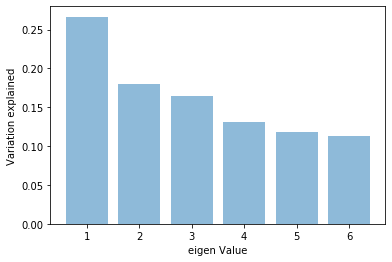

```python
plt.bar(list(range(1,7)),pca.explained_variance_ratio_,alpha=0.5, align='center')
plt.ylabel('Variation explained')
plt.xlabel('eigen Value')
plt.show()
```

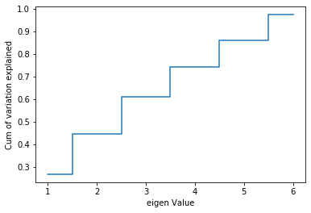

```python
plt.step(list(range(1,7)),np.cumsum(pca.explained_variance_ratio_), where='mid')
plt.ylabel('Cum of variation explained')
plt.xlabel('eigen Value')
plt.show()
```

```python
pca
```

[output not shown]

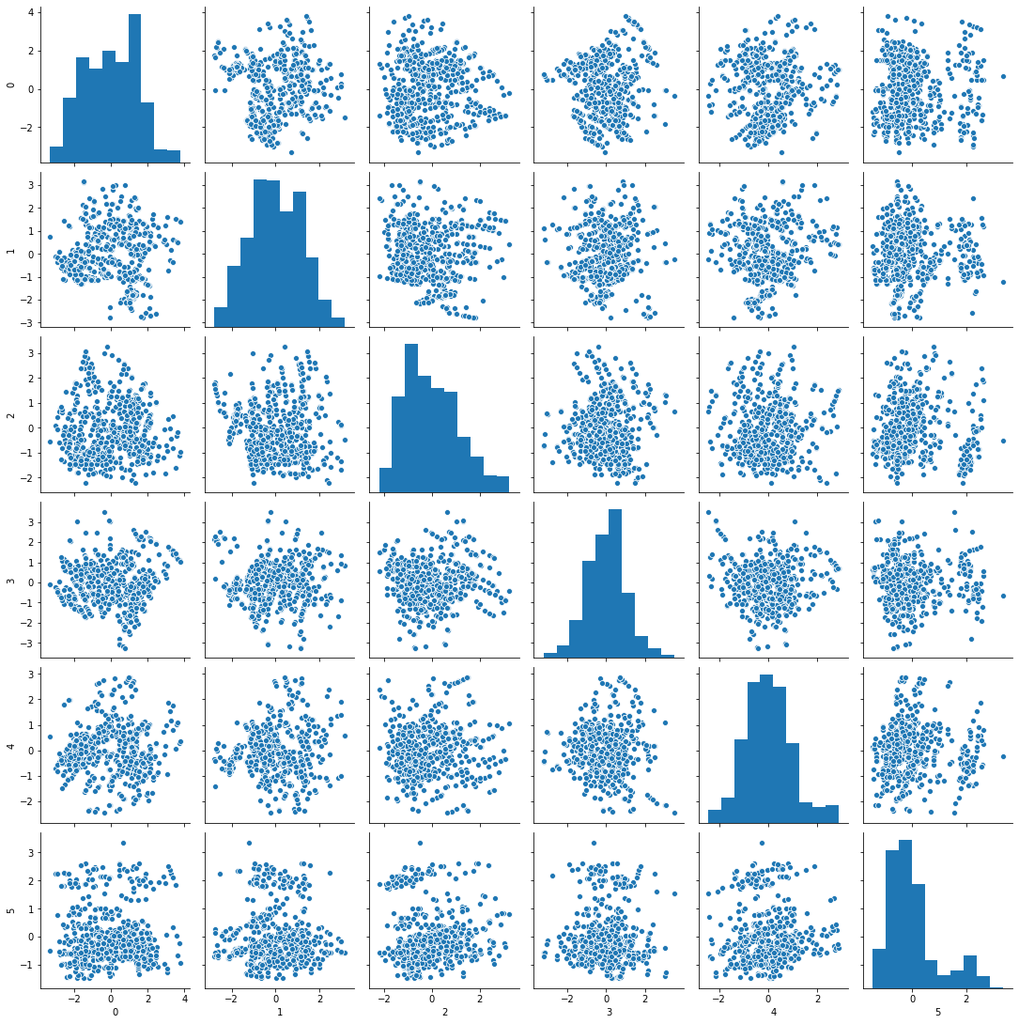

```python
xpca = pca.transform(X_train)
sns.pairplot(pd.DataFrame(xpca))
```

```python
pipeline_pca = Pipeline([
    ('pca',PCA(6)),
    ('scaler',StandardScaler()),
    ('LR_linear_pca', LinearRegression())
])

# use the pipeline object as you would
# a regular classifier
pipeline_pca.fit(X_train,y_train)
```

```
Pipeline(steps=[('pca', PCA(n_components=6)), ('scaler', StandardScaler()),
                ('LR_linear_pca', LinearRegression())])
```

```python
pipeline_pca.score(X_train,y_train)
```

```
0.725399083369126
```

```python
pipeline_pca.score(X_test,y_test)
```

```
0.7619046726226988
```

### After using PCA we get 72 % accuracy on train data and 76% accuracy on test data.

## Step 4. Deliverable -4 (Tuning the model) (20 marks)

### a. Algorithms that you think will be suitable for this project (5 marks)

Three algorithms are used:

1. Linear regression
2. SV regressor
3. Ensemble techniques a. Decision tree regressor b. Random forest regressor

### b. Techniques employed to squeeze that extra performance out of the model without making it overfit or underfit (5 marks)

Original dataset with removal of outliers and applying zscore Used SequentialFeatureSelector for the features created using polynomial terms It gives better performance on Linear regression and decision tree but not on SVR Also for original 8 features with preprocessing gives good accuracy for Linear regression model and Decision tree model

### c. Model performance range at 95% confidence level (10 marks)

Model performance is plotted for LR and Dtree models with good accuracy for the range at 95% accuracy level

### Dtree regressor using original data after preprocessing and scaling

```python
from sklearn.tree import DecisionTreeRegressor
from sklearn.preprocessing import StandardScaler
```

```python
#regressor = DecisionTreeRegressor(random_state=0, max_depth=4)

#regressor.fit(X_train , y_train)


pipeline_DTR = Pipeline([(" scaler", StandardScaler()), \
                         ("dtr", DecisionTreeRegressor(random_state=0, max_depth=4))])
pipeline_DTR.fit(X_train , y_train)
```

```
Pipeline(steps=[(' scaler', StandardScaler()),
                ('dtr', DecisionTreeRegressor(max_depth=4, random_state=0))])
```

```python
pipeline_DTR.score(X_train , y_train)
```

```
0.7510587064727865
```

```python
pipeline_DTR.score(X_test , y_test)
```

```
0.7137091747407884
```

### Dtree with use of SequentialFeatureSelector selected features

```python
regressor = DecisionTreeRegressor(random_state=0, max_depth=4)

regressor.fit(xsel_train , y_train1)
feature_importances = regressor.feature_importances_
```

```python
regressor.score(xsel_train,y_train1)
```

```
0.9745245518318159
```

```python
regressor.score(xsel_test,y_test1)
```

```
0.9548455155017418
```

### Support vector regression model on original data after preprocessing and scaling

```python
from sklearn.svm import SVR
from sklearn.preprocessing import StandardScaler
pipe_svr = Pipeline([(" scaler", StandardScaler()), (" svm", SVR())])
pipe_svr.fit(X_train , y_train)
```

```
Pipeline(steps=[(' scaler', StandardScaler()), (' svm', SVR())])
```

```python
pipe_svr.score(X_train , y_train)
```

```
0.9112666774832926
```

```python
pipe_svr.score(X_test , y_test)
```

```
0.8771431202435206
```

### with Support vector regression model on original data with scalling and preprocessing we get 91 % accuracy on train data and 87% accuracy on test data.

### Using sequential featureselector selected features SVR gives train and test accuracy of 0.60 and 0.61 respectively.

### SVR with SequentialFeatureSelector selected features

```python
model_svr = SVR()
model_svr.fit(xsel_train , y_train1)
model_svr.score(xsel_train , y_train1)
```

```
0.6009523557843542
```

```python
model_svr.score(xsel_test, y_test1)
```

```
0.6131882039180439
```

### Randomforest regressor on original data

```python
from sklearn.ensemble import RandomForestRegressor
rf_reg = RandomForestRegressor(n_estimators = 5, random_state=42,max_features=2)
rf_reg = rf_reg.fit(X_train, y_train)
rf_reg.score(X_train,y_train)
```

```
0.9549945340466431
```

```python
rf_reg.score(X_test,y_test)
```

```
0.8428181253754315
```

### Hyperparameter Tuning using GridSearchCV, RandomizedSearchCV for

#### 1. Random Forest regressor

#### 2. SVR regressor

#### 3. DT regressor

```python
rf_reg = RandomForestRegressor(n_estimators=8)
```

```python
# specify parameters and distributions to sample from
from scipy.stats import randint as sp_randint
param_dist = {"max_depth": [3, None],
              "max_features": sp_randint(1, 8),
              "min_samples_split": sp_randint(2, 8),
              "min_samples_leaf": sp_randint(1, 8),
              "bootstrap": [True, False],
              }
```

```python
# run randomized search
from sklearn.model_selection import GridSearchCV
from sklearn.model_selection import RandomizedSearchCV
samples = 10  # number of random samples
randomCV_rf = RandomizedSearchCV(rf_reg, param_distributions=param_dist, n_iter=samples) #default cv = 3
```

```python
randomCV_rf.fit(X_train, y_train)
print(randomCV_rf.best_params_)
```

```
{'bootstrap': False, 'max_depth': None, 'max_features': 3, 'min_samples_leaf': 1, 'min_samples_split': 6}
```

```python
randomCV_rf.score(X_train,y_train)
```

```
0.9823404797328233
```

```python
randomCV_rf.score(X_test,y_test)
```

```
0.8944124866720168
```

```python
print("Train accuracy with best parameters on RF",randomCV_rf.score(X_train,y_train))
print("Test accuracy with best parameters on RF",randomCV_rf.score(X_test,y_test))
```

```
Train accuracy with best parameters on RF 0.9823404797328233
Test accuracy with best parameters on RF 0.8944124866720168
```

### Hyper parameter tuning for SVR

```python
svr = SVR()
```

```python
svr.get_params().keys()
```

```
dict_keys(['C', 'cache_size', 'coef0', 'degree', 'epsilon', 'gamma', 'kernel', 'max_iter', 'shrinking', 'tol', 'verbose'])
```

```python
param_grid_svr = {'C': [0.001, 0.01, 0.1, 1, 10, 100], \
              'gamma': [0.001, 0.01, 0.1, 1, 10], \
              'kernel':['rbf','poly'],\
              'max_iter':[800,900,1000]}
```

```python
grid_svr = GridSearchCV(svr , param_grid = param_grid, cv = 5)

grid_svr.fit(X_train, y_train)
```

```
GridSearchCV(cv=5, estimator=SVR(),
             param_grid={'C': [0.001, 0.01, 0.1, 1, 10, 100],
                         'gamma': [0.001, 0.01, 0.1, 1, 10],
                         'kernel': ['rbf', 'poly'],
                         'max_iter': [800, 900, 1000]})
```

```python
print(" Best cross-validation accuracy: {:.2f}". format( grid_svr.best_score_))
print(" Best parameters: ", grid_svr.best_params_)
print(" Test set accuracy: {:.2f}". format( grid_svr.score( X_test, y_test)))
```

```
 Best cross-validation accuracy: 0.87
 Best parameters:  {'C': 10, 'gamma': 0.1, 'kernel': 'rbf', 'max_iter': 900}
 Test set accuracy: 0.89
```

### Hyperparameter tuning of Decision Tree Regressor

```python
from scipy.stats import randint
param_dist_dtr = {"max_depth": [3, None],
              "max_features": randint(1, 9),
              "min_samples_leaf": randint(1, 9),
              "criterion": ["mse", "friedman_mse", "mae", "poisson"]}

# Instantiating Decision Tree classifier
tree = DecisionTreeRegressor()

# Instantiating RandomizedSearchCV object
tree_cv = RandomizedSearchCV(tree, param_dist_dtr, cv = 5)

tree_cv.fit(X, y)

# Print the tuned parameters and score
print("Tuned Decision Tree Parameters: {}".format(tree_cv.best_params_))
print("Best score is {}".format(tree_cv.best_score_))
```

```
Tuned Decision Tree Parameters: {'criterion': 'mae', 'max_depth': None, 'max_features': 5, 'min_samples_leaf': 4}
Best score is 0.9290304397062652
```

## Performance evaluation of the models and 95 % confidence interval

```python
from sklearn.utils import resample
from sklearn.metrics import r2_score
```

```python
values = Data3.values
```

```python
# configure bootstrap
n_iterations = 1000              # Number of bootstrap samples to create
n_size = int(len(Data3) * 0.50)    # picking only 50 % of the given data in every bootstrap sample

# run bootstrap
stats = list()
for i in range(n_iterations):
    # prepare train and test sets

    train = resample(values, n_samples=n_size)  # Sampling with replacement
    test = np.array([x for x in values if x.tolist() not in train.tolist()])  # picking rest of the data not considered in sample
    # fit model
    model = DecisionTreeRegressor()
    model.fit(train[:,:-1], train[:,-1])
    # evaluate model
    predictions = model.predict(test[:,:-1])
    score = r2_score(test[:,-1], predictions)    # caution, overall accuracy score can mislead when classes are imbalanced
    if i%10==0:
        print(score)
    stats.append(score)
```

[output not shown]

[output cut: 945 more lines]

```
0.9840368347412967
0.9525765319616125
0.97578874495187
0.9827493962384699
0.9267940202092603
0.9740076308863365
0.9338530225780496
0.9597796580341849
0.972993600459269
0.9816241793617988
0.9769088406574578
0.9746386555044729
0.9775156719074508
0.9798737151602459
0.9737800918953422
```

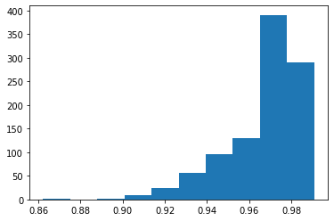

```
95.0 confidence interval 92.1% and 98.6%
```

```python
# plot scores

plt.hist(stats)
plt.show()
# confidence intervals
alpha = 0.95                             # for 95% confidence
p = ((1.0-alpha)/2.0) * 100              # tail regions on right and left .25 on each side indicated by P value (border)
lower = max(0.0, np.percentile(stats, p))
p = (alpha+((1.0-alpha)/2.0)) * 100
upper = min(1.0, np.percentile(stats, p))
print('%.1f confidence interval %.1f%% and %.1f%%' % (alpha*100, lower*100, upper*100))
```

```python
# configure bootstrap
n_iterations = 100              # Number of bootstrap samples to create
n_size = int(len(Data3) * 0.50)    # picking only 50 % of the given data in every bootstrap sample

# run bootstrap
stats = list()
for i in range(n_iterations):
    # prepare train and test sets

    train = resample(values, n_samples=n_size)  # Sampling with replacement
    test = np.array([x for x in values if x.tolist() not in train.tolist()])  # picking rest of the data not considered in sample
    # fit model
    modelLR = LinearRegression()
    modelLR.fit(train[:,:-1], train[:,-1])
    # evaluate model
    predictions = modelLR.predict(test[:,:-1])
    score = r2_score(test[:,-1], predictions)    # caution, overall accuracy score can mislead when classes are imbalanced
    if i%10==0:
        print(score)
    stats.append(score)
```

```
0.9449119437993401
0.9674134384033849
0.9710855129680527
0.8894656663013674
0.9728417236066191
0.812791428391503
0.956672028804895
0.955486222348878
0.9674948934475667
0.9405227599196156
```

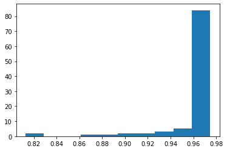

```
95.0 confidence interval 88.0% and 97.3%
```

```python
# plot scores

plt.hist(stats)
plt.show()
# confidence intervals
alpha = 0.95                             # for 95% confidence
p = ((1.0-alpha)/2.0) * 100              # tail regions on right and left .25 on each side indicated by P value (border)
lower = max(0.0, np.percentile(stats, p))
p = (alpha+((1.0-alpha)/2.0)) * 100
upper = min(1.0, np.percentile(stats, p))
print('%.1f confidence interval %.1f%% and %.1f%%' % (alpha*100, lower*100, upper*100))
```

### Linear regression model performance for polynomial features

```python
values = output_df.values
```

```python
# configure bootstrap
n_iterations = 100              # Number of bootstrap samples to create
n_size = int(len(output_df) * 0.50)    # picking only 50 % of the given data in every bootstrap sample

# run bootstrap
stats1 = list()
for i in range(n_iterations):
    # prepare train and test sets

    train = resample(values, n_samples=n_size)  # Sampling with replacement
    test = np.array([x for x in values if x.tolist() not in train.tolist()])  # picking rest of the data not considered in sample
    # fit model
    modelLR = LinearRegression()
    modelLR.fit(train[:,:-1], train[:,-1])
    # evaluate model
    predictions = modelLR.predict(test[:,:-1])
    score1 = r2_score(test[:,-1], predictions)    # caution, overall accuracy score can mislead when classes are imbalanced
    if i%10==0:
        print(score1)
    stats1.append(score1)
```

```
0.9998997630259505
0.9999258382764724
0.9999267955916671
0.9999185291806363
0.9999162093353452
0.9998316110762868
0.9999037719021389
0.9999067369723089
0.9998085153796555
0.9999066275959039
```

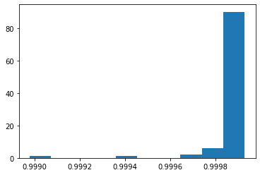

```
95.0 confidence interval 100.0% and 100.0%
```

```python
# plot scores

plt.hist(stats1)
plt.show()
# confidence intervals
alpha = 0.95                             # for 95% confidence
p = ((1.0-alpha)/2.0) * 100              # tail regions on right and left .25 on each side indicated by P value (border)
lower = max(0.0, np.percentile(stats1, p))
p = (alpha+((1.0-alpha)/2.0)) * 100
upper = min(1.0, np.percentile(stats1, p))
print('%.1f confidence interval %.1f%% and %.1f%%' % (alpha*100, lower*100, upper*100))
```

### model performance of Decision tree regressor for polynomial features

```python
# configure bootstrap
n_iterations = 100              # Number of bootstrap samples to create
n_size = int(len(Data3) * 0.50)    # picking only 50 % of the given data in every bootstrap sample

# run bootstrap
stats = list()
for i in range(n_iterations):
    # prepare train and test sets

    train = resample(values, n_samples=n_size)  # Sampling with replacement
    test = np.array([x for x in values if x.tolist() not in train.tolist()])  # picking rest of the data not considered in sample
    # fit model
    model = DecisionTreeRegressor()
    model.fit(train[:,:-1], train[:,-1])
    # evaluate model
    predictions = model.predict(test[:,:-1])
    score = r2_score(test[:,-1], predictions)    # caution, overall accuracy score can mislead when classes are imbalanced
    if i%10==0:
        print(score)
    stats.append(score)
```

```
0.9763155682651257
0.9740105465983908
0.9738286545083252
0.9777812988523945
0.9726501869880623
0.9725753603362786
0.9801907227836485
0.9748401380025224
0.9693033486913709
0.9750463273058063
```

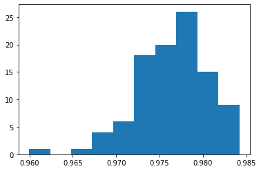

```
95.0 confidence interval 96.7% and 98.3%
```

```python
# plot scores

plt.hist(stats)
plt.show()
# confidence intervals
alpha = 0.95                             # for 95% confidence
p = ((1.0-alpha)/2.0) * 100              # tail regions on right and left .25 on each side indicated by P value (border)
lower = max(0.0, np.percentile(stats, p))
p = (alpha+((1.0-alpha)/2.0)) * 100
upper = min(1.0, np.percentile(stats, p))
print('%.1f confidence interval %.1f%% and %.1f%%' % (alpha*100, lower*100, upper*100))
```

### Performance of the models

```python
print("Train accuracy LR-linear model,standard scaling", pipeline_LR.score(X_train,y_train))
print("Test accuracy LR - linear model,standard scaling",pipeline_LR.score(X_test,y_test))
```

```
Train accuracy LR-linear model,standard scaling 0.7642772575377559
Test accuracy LR - linear model,standard scaling 0.7751382129341633
```

```python
print("Train accuracy Polynomial LR(degree 2 and only interaction terms)",pipeline_PLR.score(X_train1, y_train1))
print("Test accuracy Polynomial LR(degree 2 and only interaction terms)",pipeline_PLR.score(X_test1, y_test1))
```

```
Train accuracy Polynomial LR(degree 2 and only interaction terms) 0.9999500768406955
Test accuracy Polynomial LR(degree 2 and only interaction terms) 0.9999127222808513
```

```python
print("Train accuracy LR with PCA",pipeline_pca.score(X_train,y_train))
print("Test accuracy LR with PCA",pipeline_pca.score(X_test,y_test))
```

```
Train accuracy LR with PCA 0.725399083369126
Test accuracy LR with PCA 0.7619046726226988
```

```python
print("Train accuracy LR on selected features using SequentialFeatureSelector",LR.score(xsel_train, y_train1))
print("Test accuracy LR on selected features using SequentialFeatureSelector",LR.score(xsel_test, y_test1))
```

```
Train accuracy LR on selected features using SequentialFeatureSelector 0.9997111903915499
Test accuracy LR on selected features using SequentialFeatureSelector 0.9996261446370437
```

```python
print("Train accuracy of DTress  regressor on selected features from polynomial terms ",regressor.score(xsel_train,y_train1))
print("Test accuracy of DTress  regressor on selected features from polynomial terms ",regressor.score(xsel_test,y_test1))
```

```
Train accuracy of DTress  regressor on selected features from polynomial terms  0.9745245518318159
Test accuracy of DTress  regressor on selected features from polynomial terms  0.9548455155017418
```

```python
print("Train accuracy on DTree regressor",pipeline_DTR.score(X_train , y_train))
print("Train accuracy on DTree regressor",pipeline_DTR.score(X_test , y_test))
```

```
Train accuracy on DTree regressor 0.7510587064727865
Train accuracy on DTree regressor 0.7137091747407884
```

```python
print("Train accuracy on SVR",pipe_svr.score(X_train , y_train))
print("Test accuracy on SVR",pipe_svr.score(X_test , y_test))
```

```
Train accuracy on SVR 0.9112666774832926
Test accuracy on SVR 0.8771431202435206
```

```python
print("Train accuracy of SVR on selected features",model_svr.score(xsel_train , y_train1))
print("Test accuracy of SVR on selected features",model_svr.score(xsel_test, y_test1))
```

```
Train accuracy of SVR on selected features 0.6009523557843542
Test accuracy of SVR on selected features 0.6131882039180439
```

```python
print("Train accuracy of Random forest regressor",rf_reg.score(X_train,y_train))
print("Test accuracy of Random forest regressor",rf_reg.score(X_test,y_test))
```

[output not shown]

```python
print("SVR Best cross-validation accuracy: {:.2f}". format( grid_svr.best_score_))
print("SVR Best parameters: ", grid_svr.best_params_)
print("SVR Test set accuracy: {:.2f}". format( grid_svr.score( X_test, y_test)))
```

[output not shown]

```python
print("Tuned Decision Tree Parameters: {}".format(tree_cv.best_params_))
print("DTR Best score is {}".format(tree_cv.best_score_))
```

[output not shown]

```python
print("Train accuracy with best parameters on RF",randomCV_rf.score(X_train,y_train))
print("Test accuracy with best parameters on RF",randomCV_rf.score(X_test,y_test))
```

```
Train accuracy with best parameters on RF 0.9823404797328233
Test accuracy with best parameters on RF 0.8944124866720168
```

## Conclusion and observations

Five models have been tested on all the original features after removal of outliers and scaling was applied.

### After Hyperparameter tuning:

Test accuracy of SVR = 89 on original preprocessed and scaled data Decision tree best score is 92 Random forest shows Train accuracy with best parameters on RF= 98 Test accuracy with best parameters on RF= 89

### 95% confidence interval:

1. LR shows 95.0 confidence interval 88.0% and 97.3%
2. LR with polynomial terms shows 95.0 confidence interval 100.0% and 100.0%
3. DTree shows 95.0 confidence interval 92.1% and 98.6%
4. DTree with polynomial terms shows 95.0 confidence interval 96.7% and 98.3%